# Risk Factor Analysis

## Outcome Variable

**Outcome Variable:** stunted

## Predictor Variables

**Intervention Variable:** mwtkg

**Adjustment Set:**

- arm
- W_mage
- W_fage
- meducyrs
- feducyrs
- single
- brthmon
- delta_W_mage
- delta_W_fage
- delta_meducyrs
- delta_feducyrs
- delta_single
- delta_brthmon

## Stratifying Variables

The analysis was stratified on these variable(s):

- agecat
- studyid
- country

## Data Summary

| agecat | studyid | country | mwtkg | stunted | n_cell | n |
| --- | --- | --- | --- | --- | --- | --- |
| Birth | ki0047075b-MAL-ED | BANGLADESH | >=58 kg | 0 | 40 | 246 |
| Birth | ki0047075b-MAL-ED | BANGLADESH | >=58 kg | 1 | 7 | 246 |
| Birth | ki0047075b-MAL-ED | BANGLADESH | <52 kg | 0 | 126 | 246 |
| Birth | ki0047075b-MAL-ED | BANGLADESH | <52 kg | 1 | 30 | 246 |
| Birth | ki0047075b-MAL-ED | BANGLADESH | [52-58) kg | 0 | 38 | 246 |
| Birth | ki0047075b-MAL-ED | BANGLADESH | [52-58) kg | 1 | 5 | 246 |
| Birth | ki0047075b-MAL-ED | BRAZIL | >=58 kg | 0 | 110 | 184 |
| Birth | ki0047075b-MAL-ED | BRAZIL | >=58 kg | 1 | 11 | 184 |
| Birth | ki0047075b-MAL-ED | BRAZIL | <52 kg | 0 | 28 | 184 |
| Birth | ki0047075b-MAL-ED | BRAZIL | <52 kg | 1 | 5 | 184 |
| Birth | ki0047075b-MAL-ED | BRAZIL | [52-58) kg | 0 | 27 | 184 |
| Birth | ki0047075b-MAL-ED | BRAZIL | [52-58) kg | 1 | 3 | 184 |
| Birth | ki0047075b-MAL-ED | INDIA | >=58 kg | 0 | 33 | 198 |
| Birth | ki0047075b-MAL-ED | INDIA | >=58 kg | 1 | 3 | 198 |
| Birth | ki0047075b-MAL-ED | INDIA | <52 kg | 0 | 101 | 198 |
| Birth | ki0047075b-MAL-ED | INDIA | <52 kg | 1 | 22 | 198 |
| Birth | ki0047075b-MAL-ED | INDIA | [52-58) kg | 0 | 32 | 198 |
| Birth | ki0047075b-MAL-ED | INDIA | [52-58) kg | 1 | 7 | 198 |
| Birth | ki0047075b-MAL-ED | NEPAL | >=58 kg | 0 | 50 | 172 |
| Birth | ki0047075b-MAL-ED | NEPAL | >=58 kg | 1 | 7 | 172 |
| Birth | ki0047075b-MAL-ED | NEPAL | <52 kg | 0 | 43 | 172 |
| Birth | ki0047075b-MAL-ED | NEPAL | <52 kg | 1 | 9 | 172 |
| Birth | ki0047075b-MAL-ED | NEPAL | [52-58) kg | 0 | 61 | 172 |
| Birth | ki0047075b-MAL-ED | NEPAL | [52-58) kg | 1 | 2 | 172 |
| Birth | ki0047075b-MAL-ED | PERU | >=58 kg | 0 | 91 | 276 |
| Birth | ki0047075b-MAL-ED | PERU | >=58 kg | 1 | 8 | 276 |
| Birth | ki0047075b-MAL-ED | PERU | <52 kg | 0 | 89 | 276 |
| Birth | ki0047075b-MAL-ED | PERU | <52 kg | 1 | 18 | 276 |
| Birth | ki0047075b-MAL-ED | PERU | [52-58) kg | 0 | 63 | 276 |
| Birth | ki0047075b-MAL-ED | PERU | [52-58) kg | 1 | 7 | 276 |

[output cut: 216 more lines]

The following strata were considered:

- agecat: 24 months, studyid: ki0047075b-MAL-ED, country: BANGLADESH
- agecat: 24 months, studyid: ki0047075b-MAL-ED, country: BRAZIL
- agecat: 24 months, studyid: ki0047075b-MAL-ED, country: INDIA
- agecat: 24 months, studyid: ki0047075b-MAL-ED, country: NEPAL
- agecat: 24 months, studyid: ki0047075b-MAL-ED, country: PERU
- agecat: 24 months, studyid: ki0047075b-MAL-ED, country: SOUTH AFRICA
- agecat: 24 months, studyid: ki0047075b-MAL-ED, country: TANZANIA, UNITED REPUBLIC OF
- agecat: 24 months, studyid: ki1017093-NIH-Birth, country: BANGLADESH
- agecat: 24 months, studyid: ki1017093b-PROVIDE, country: BANGLADESH
- agecat: 24 months, studyid: ki1017093c-NIH-Crypto, country: BANGLADESH
- agecat: 24 months, studyid: ki1066203-TanzaniaChild2, country: TANZANIA, UNITED REPUBLIC OF
- agecat: 24 months, studyid: ki1119695-PROBIT, country: BELARUS
- agecat: 24 months, studyid: ki1126311-ZVITAMBO, country: ZIMBABWE
- agecat: 24 months, studyid: ki1148112-LCNI-5, country: MALAWI
- agecat: 6 months, studyid: ki0047075b-MAL-ED, country: BANGLADESH
- agecat: 6 months, studyid: ki0047075b-MAL-ED, country: BRAZIL
- agecat: 6 months, studyid: ki0047075b-MAL-ED, country: INDIA
- agecat: 6 months, studyid: ki0047075b-MAL-ED, country: NEPAL
- agecat: 6 months, studyid: ki0047075b-MAL-ED, country: PERU
- agecat: 6 months, studyid: ki0047075b-MAL-ED, country: SOUTH AFRICA
- agecat: 6 months, studyid: ki0047075b-MAL-ED, country: TANZANIA, UNITED REPUBLIC OF
- agecat: 6 months, studyid: ki1000304b-SAS-CompFeed, country: INDIA
- agecat: 6 months, studyid: ki1017093-NIH-Birth, country: BANGLADESH
- agecat: 6 months, studyid: ki1017093b-PROVIDE, country: BANGLADESH
- agecat: 6 months, studyid: ki1017093c-NIH-Crypto, country: BANGLADESH
- agecat: 6 months, studyid: ki1066203-TanzaniaChild2, country: TANZANIA, UNITED REPUBLIC OF
- agecat: 6 months, studyid: ki1119695-PROBIT, country: BELARUS
- agecat: 6 months, studyid: ki1126311-ZVITAMBO, country: ZIMBABWE
- agecat: 6 months, studyid: ki1148112-LCNI-5, country: MALAWI
- agecat: Birth, studyid: ki0047075b-MAL-ED, country: BANGLADESH
- agecat: Birth, studyid: ki0047075b-MAL-ED, country: BRAZIL
- agecat: Birth, studyid: ki0047075b-MAL-ED, country: INDIA
- agecat: Birth, studyid: ki0047075b-MAL-ED, country: NEPAL
- agecat: Birth, studyid: ki0047075b-MAL-ED, country: PERU
- agecat: Birth, studyid: ki0047075b-MAL-ED, country: SOUTH AFRICA
- agecat: Birth, studyid: ki0047075b-MAL-ED, country: TANZANIA, UNITED REPUBLIC OF
- agecat: Birth, studyid: ki1000304b-SAS-CompFeed, country: INDIA
- agecat: Birth, studyid: ki1017093-NIH-Birth, country: BANGLADESH
- agecat: Birth, studyid: ki1017093c-NIH-Crypto, country: BANGLADESH
- agecat: Birth, studyid: ki1119695-PROBIT, country: BELARUS
- agecat: Birth, studyid: ki1126311-ZVITAMBO, country: ZIMBABWE

### Dropped Strata

Some strata were dropped due to rare outcomes:

- agecat: Birth, studyid: ki0047075b-MAL-ED, country: BRAZIL
- agecat: Birth, studyid: ki0047075b-MAL-ED, country: INDIA
- agecat: Birth, studyid: ki0047075b-MAL-ED, country: NEPAL
- agecat: Birth, studyid: ki0047075b-MAL-ED, country: SOUTH AFRICA
- agecat: Birth, studyid: ki1000304b-SAS-CompFeed, country: INDIA
- agecat: Birth, studyid: ki1017093-NIH-Birth, country: BANGLADESH
- agecat: Birth, studyid: ki1017093c-NIH-Crypto, country: BANGLADESH
- agecat: 6 months, studyid: ki0047075b-MAL-ED, country: BANGLADESH
- agecat: 6 months, studyid: ki0047075b-MAL-ED, country: BRAZIL
- agecat: 6 months, studyid: ki0047075b-MAL-ED, country: INDIA
- agecat: 6 months, studyid: ki0047075b-MAL-ED, country: NEPAL
- agecat: 24 months, studyid: ki0047075b-MAL-ED, country: BRAZIL
- agecat: 24 months, studyid: ki1066203-TanzaniaChild2, country: TANZANIA, UNITED REPUBLIC OF

## Methods Detail

We’re interested in the causal parameters $E[Y_a]$ for all values of $a \in \mathcal{A}$. These parameters represent the mean outcome if, possibly contrary to fact, we intervened to set all units to have $A=a$. Under the randomization and positivity assumptions, these are identified by the statistical parameters $\psi_a=E_W[E_{Y|A,W}(Y|A=a,W)]$. In addition, we’re interested in the mean of $Y$, $E[Y]$ under no intervention (the observed mean). We will estimate these parameters by using SuperLearner to fit the relevant likelihood factors – $E_{Y|A,W}(Y|A=a,W)$ and $p(A=a|W)$, and then updating our likelihood fit using a joint TMLE.

For unadjusted analyses ($W=\{\}$), initial likelihoods were estimated using Lrnr_glm to estimate the simple $E(Y|A)$ and Lrnr_mean to estimate $p(A)$. For adjusted analyses, a small library containing Lrnr_glmnet, Lrnr_xgboost, and Lrnr_mean was used.

Having estimated these parameters, we will then use the delta method to estimate relative risks and attributable risks relative to a prespecified baseline level of $A$.

# Results Detail

## Results Plots

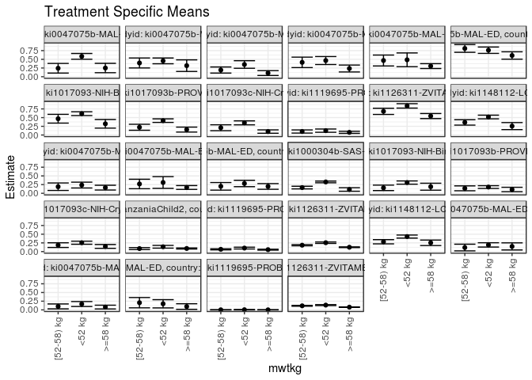

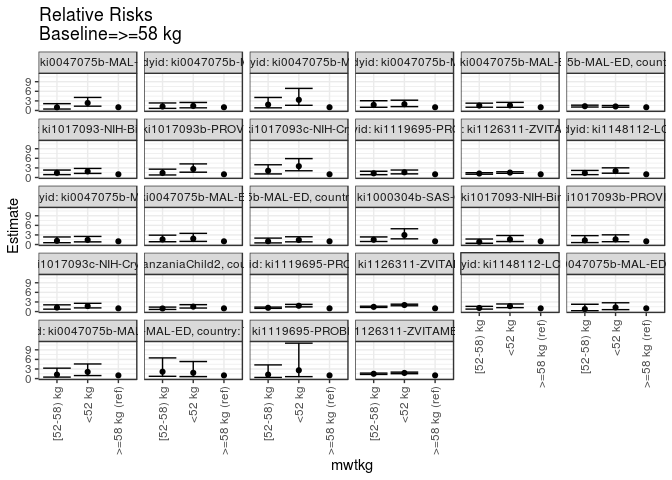

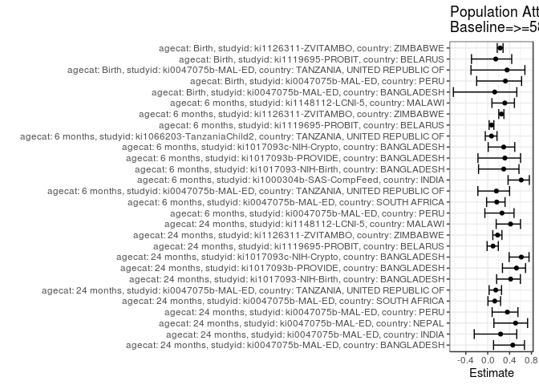

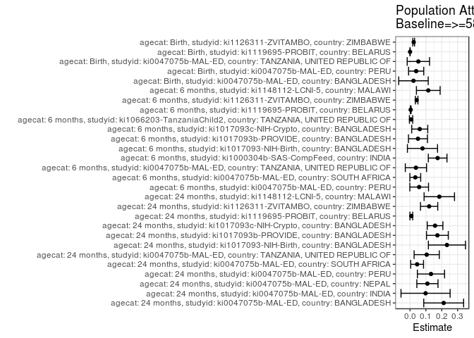

## Results Table

### Parameter: TSM

| agecat | studyid | country | intervention_level | baseline_level | estimate | ci_lower | ci_upper |
| --- | --- | --- | --- | --- | --- | --- | --- |
| Birth | ki0047075b-MAL-ED | BANGLADESH | >=58 kg | NA | 0.1489362 | 0.0469445 | 0.2509279 |
| Birth | ki0047075b-MAL-ED | BANGLADESH | <52 kg | NA | 0.1923077 | 0.1303362 | 0.2542791 |
| Birth | ki0047075b-MAL-ED | BANGLADESH | [52-58) kg | NA | 0.1162791 | 0.0202712 | 0.2122869 |
| Birth | ki0047075b-MAL-ED | PERU | >=58 kg | NA | 0.0808081 | 0.0270246 | 0.1345916 |
| Birth | ki0047075b-MAL-ED | PERU | <52 kg | NA | 0.1682243 | 0.0972188 | 0.2392298 |
| Birth | ki0047075b-MAL-ED | PERU | [52-58) kg | NA | 0.1000000 | 0.0295942 | 0.1704058 |
| Birth | ki0047075b-MAL-ED | TANZANIA, UNITED REPUBLIC OF | >=58 kg | NA | 0.0961538 | 0.0156940 | 0.1766137 |
| Birth | ki0047075b-MAL-ED | TANZANIA, UNITED REPUBLIC OF | <52 kg | NA | 0.1750000 | 0.0567595 | 0.2932405 |
| Birth | ki0047075b-MAL-ED | TANZANIA, UNITED REPUBLIC OF | [52-58) kg | NA | 0.2068966 | 0.0588519 | 0.3549412 |
| Birth | ki1119695-PROBIT | BELARUS | >=58 kg | NA | 0.0020440 | 0.0003496 | 0.0037384 |
| Birth | ki1119695-PROBIT | BELARUS | <52 kg | NA | 0.0053050 | -0.0001768 | 0.0107869 |
| Birth | ki1119695-PROBIT | BELARUS | [52-58) kg | NA | 0.0025402 | 0.0003101 | 0.0047704 |
| Birth | ki1126311-ZVITAMBO | ZIMBABWE | >=58 kg | NA | 0.0780488 | 0.0710417 | 0.0850559 |
| Birth | ki1126311-ZVITAMBO | ZIMBABWE | <52 kg | NA | 0.1376144 | 0.1233359 | 0.1518929 |
| Birth | ki1126311-ZVITAMBO | ZIMBABWE | [52-58) kg | NA | 0.1170775 | 0.1050750 | 0.1290800 |
| 6 months | ki0047075b-MAL-ED | PERU | >=58 kg | NA | 0.1628820 | 0.0944299 | 0.2313342 |
| 6 months | ki0047075b-MAL-ED | PERU | <52 kg | NA | 0.2367274 | 0.1531420 | 0.3203128 |
| 6 months | ki0047075b-MAL-ED | PERU | [52-58) kg | NA | 0.1896908 | 0.0819934 | 0.2973883 |
| 6 months | ki0047075b-MAL-ED | SOUTH AFRICA | >=58 kg | NA | 0.1675978 | 0.1127706 | 0.2224250 |
| 6 months | ki0047075b-MAL-ED | SOUTH AFRICA | <52 kg | NA | 0.3103448 | 0.1416269 | 0.4790627 |
| 6 months | ki0047075b-MAL-ED | SOUTH AFRICA | [52-58) kg | NA | 0.2682927 | 0.1323978 | 0.4041876 |
| 6 months | ki0047075b-MAL-ED | TANZANIA, UNITED REPUBLIC OF | >=58 kg | NA | 0.1975141 | 0.1155797 | 0.2794485 |
| 6 months | ki0047075b-MAL-ED | TANZANIA, UNITED REPUBLIC OF | <52 kg | NA | 0.2821156 | 0.1902670 | 0.3739643 |
| 6 months | ki0047075b-MAL-ED | TANZANIA, UNITED REPUBLIC OF | [52-58) kg | NA | 0.2002151 | 0.0907635 | 0.3096667 |
| 6 months | ki1000304b-SAS-CompFeed | INDIA | >=58 kg | NA | 0.1099867 | 0.0593871 | 0.1605863 |
| 6 months | ki1000304b-SAS-CompFeed | INDIA | <52 kg | NA | 0.3263384 | 0.3013464 | 0.3513304 |
| 6 months | ki1000304b-SAS-CompFeed | INDIA | [52-58) kg | NA | 0.1644945 | 0.1264668 | 0.2025223 |
| 6 months | ki1017093-NIH-Birth | BANGLADESH | >=58 kg | NA | 0.1895663 | 0.0893134 | 0.2898192 |
| 6 months | ki1017093-NIH-Birth | BANGLADESH | <52 kg | NA | 0.3083907 | 0.2621114 | 0.3546701 |
| 6 months | ki1017093-NIH-Birth | BANGLADESH | [52-58) kg | NA | 0.1566071 | 0.0781061 | 0.2351082 |

[output cut: 54 more lines]

### Parameter: E(Y)

| agecat | studyid | country | intervention_level | baseline_level | estimate | ci_lower | ci_upper |
| --- | --- | --- | --- | --- | --- | --- | --- |
| Birth | ki0047075b-MAL-ED | BANGLADESH | NA | NA | 0.1707317 | 0.1236156 | 0.2178478 |
| Birth | ki0047075b-MAL-ED | PERU | NA | NA | 0.1195652 | 0.0812181 | 0.1579123 |
| Birth | ki0047075b-MAL-ED | TANZANIA, UNITED REPUBLIC OF | NA | NA | 0.1487603 | 0.0850915 | 0.2124292 |
| Birth | ki1119695-PROBIT | BELARUS | NA | NA | 0.0023970 | 0.0011029 | 0.0036912 |
| Birth | ki1126311-ZVITAMBO | ZIMBABWE | NA | NA | 0.1012739 | 0.0956332 | 0.1069146 |
| 6 months | ki0047075b-MAL-ED | PERU | NA | NA | 0.2205882 | 0.1712211 | 0.2699554 |
| 6 months | ki0047075b-MAL-ED | SOUTH AFRICA | NA | NA | 0.2008032 | 0.1509453 | 0.2506612 |
| 6 months | ki0047075b-MAL-ED | TANZANIA, UNITED REPUBLIC OF | NA | NA | 0.2348178 | 0.1818480 | 0.2877876 |
| 6 months | ki1000304b-SAS-CompFeed | INDIA | NA | NA | 0.2842105 | 0.2659845 | 0.3024365 |
| 6 months | ki1017093-NIH-Birth | BANGLADESH | NA | NA | 0.2681564 | 0.2306532 | 0.3056597 |
| 6 months | ki1017093b-PROVIDE | BANGLADESH | NA | NA | 0.1597938 | 0.1299995 | 0.1895881 |
| 6 months | ki1017093c-NIH-Crypto | BANGLADESH | NA | NA | 0.2097902 | 0.1799252 | 0.2396552 |
| 6 months | ki1066203-TanzaniaChild2 | TANZANIA, UNITED REPUBLIC OF | NA | NA | 0.0965309 | 0.0835493 | 0.1095126 |
| 6 months | ki1119695-PROBIT | BELARUS | NA | NA | 0.0598408 | 0.0469716 | 0.0727101 |
| 6 months | ki1126311-ZVITAMBO | ZIMBABWE | NA | NA | 0.1668346 | 0.1586345 | 0.1750346 |
| 6 months | ki1148112-LCNI-5 | MALAWI | NA | NA | 0.3679809 | 0.3352903 | 0.4006715 |
| 24 months | ki0047075b-MAL-ED | BANGLADESH | NA | NA | 0.4622642 | 0.3949918 | 0.5295365 |
| 24 months | ki0047075b-MAL-ED | INDIA | NA | NA | 0.4159292 | 0.3515272 | 0.4803312 |
| 24 months | ki0047075b-MAL-ED | NEPAL | NA | NA | 0.2149123 | 0.1614774 | 0.2683472 |
| 24 months | ki0047075b-MAL-ED | PERU | NA | NA | 0.3681592 | 0.3013164 | 0.4350020 |
| 24 months | ki0047075b-MAL-ED | SOUTH AFRICA | NA | NA | 0.3504274 | 0.2891665 | 0.4116882 |
| 24 months | ki0047075b-MAL-ED | TANZANIA, UNITED REPUBLIC OF | NA | NA | 0.7149533 | 0.6543278 | 0.7755787 |
| 24 months | ki1017093-NIH-Birth | BANGLADESH | NA | NA | 0.5547786 | 0.5076945 | 0.6018626 |
| 24 months | ki1017093b-PROVIDE | BANGLADESH | NA | NA | 0.3281250 | 0.2897474 | 0.3665026 |
| 24 months | ki1017093c-NIH-Crypto | BANGLADESH | NA | NA | 0.2568093 | 0.2190047 | 0.2946140 |
| 24 months | ki1119695-PROBIT | BELARUS | NA | NA | 0.0852230 | 0.0552609 | 0.1151851 |
| 24 months | ki1126311-ZVITAMBO | ZIMBABWE | NA | NA | 0.6651376 | 0.6207877 | 0.7094875 |
| 24 months | ki1148112-LCNI-5 | MALAWI | NA | NA | 0.4411765 | 0.4006626 | 0.4816903 |

### Parameter: RR

| agecat | studyid | country | intervention_level | baseline_level | estimate | ci_lower | ci_upper |
| --- | --- | --- | --- | --- | --- | --- | --- |
| Birth | ki0047075b-MAL-ED | BANGLADESH | >=58 kg | >=58 kg | 1.0000000 | 1.0000000 | 1.000000 |
| Birth | ki0047075b-MAL-ED | BANGLADESH | <52 kg | >=58 kg | 1.2912088 | 0.6057693 | 2.752236 |
| Birth | ki0047075b-MAL-ED | BANGLADESH | [52-58) kg | >=58 kg | 0.7807309 | 0.2670760 | 2.282275 |
| Birth | ki0047075b-MAL-ED | PERU | >=58 kg | >=58 kg | 1.0000000 | 1.0000000 | 1.000000 |
| Birth | ki0047075b-MAL-ED | PERU | <52 kg | >=58 kg | 2.0817757 | 0.9465750 | 4.578391 |
| Birth | ki0047075b-MAL-ED | PERU | [52-58) kg | >=58 kg | 1.2375000 | 0.4696521 | 3.260725 |
| Birth | ki0047075b-MAL-ED | TANZANIA, UNITED REPUBLIC OF | >=58 kg | >=58 kg | 1.0000000 | 1.0000000 | 1.000000 |
| Birth | ki0047075b-MAL-ED | TANZANIA, UNITED REPUBLIC OF | <52 kg | >=58 kg | 1.8199999 | 0.6208455 | 5.335304 |
| Birth | ki0047075b-MAL-ED | TANZANIA, UNITED REPUBLIC OF | [52-58) kg | >=58 kg | 2.1517241 | 0.7155263 | 6.470644 |
| Birth | ki1119695-PROBIT | BELARUS | >=58 kg | >=58 kg | 1.0000000 | 1.0000000 | 1.000000 |
| Birth | ki1119695-PROBIT | BELARUS | <52 kg | >=58 kg | 2.5954276 | 0.6078635 | 11.081836 |
| Birth | ki1119695-PROBIT | BELARUS | [52-58) kg | >=58 kg | 1.2427725 | 0.3611349 | 4.276749 |
| Birth | ki1126311-ZVITAMBO | ZIMBABWE | >=58 kg | >=58 kg | 1.0000000 | 1.0000000 | 1.000000 |
| Birth | ki1126311-ZVITAMBO | ZIMBABWE | <52 kg | >=58 kg | 1.7631835 | 1.5370795 | 2.022547 |
| Birth | ki1126311-ZVITAMBO | ZIMBABWE | [52-58) kg | >=58 kg | 1.5000549 | 1.3089472 | 1.719064 |
| 6 months | ki0047075b-MAL-ED | PERU | >=58 kg | >=58 kg | 1.0000000 | 1.0000000 | 1.000000 |
| 6 months | ki0047075b-MAL-ED | PERU | <52 kg | >=58 kg | 1.4533672 | 0.8345849 | 2.530930 |
| 6 months | ki0047075b-MAL-ED | PERU | [52-58) kg | >=58 kg | 1.1645902 | 0.5742721 | 2.361721 |
| 6 months | ki0047075b-MAL-ED | SOUTH AFRICA | >=58 kg | >=58 kg | 1.0000000 | 1.0000000 | 1.000000 |
| 6 months | ki0047075b-MAL-ED | SOUTH AFRICA | <52 kg | >=58 kg | 1.8517241 | 0.9818013 | 3.492440 |
| 6 months | ki0047075b-MAL-ED | SOUTH AFRICA | [52-58) kg | >=58 kg | 1.6008130 | 0.8759360 | 2.925559 |
| 6 months | ki0047075b-MAL-ED | TANZANIA, UNITED REPUBLIC OF | >=58 kg | >=58 kg | 1.0000000 | 1.0000000 | 1.000000 |
| 6 months | ki0047075b-MAL-ED | TANZANIA, UNITED REPUBLIC OF | <52 kg | >=58 kg | 1.4283318 | 0.8415017 | 2.424394 |
| 6 months | ki0047075b-MAL-ED | TANZANIA, UNITED REPUBLIC OF | [52-58) kg | >=58 kg | 1.0136752 | 0.5098921 | 2.015206 |
| 6 months | ki1000304b-SAS-CompFeed | INDIA | >=58 kg | >=58 kg | 1.0000000 | 1.0000000 | 1.000000 |
| 6 months | ki1000304b-SAS-CompFeed | INDIA | <52 kg | >=58 kg | 2.9670723 | 1.7860055 | 4.929166 |
| 6 months | ki1000304b-SAS-CompFeed | INDIA | [52-58) kg | >=58 kg | 1.4955861 | 0.9417800 | 2.375054 |
| 6 months | ki1017093-NIH-Birth | BANGLADESH | >=58 kg | >=58 kg | 1.0000000 | 1.0000000 | 1.000000 |
| 6 months | ki1017093-NIH-Birth | BANGLADESH | <52 kg | >=58 kg | 1.6268225 | 0.9389143 | 2.818736 |
| 6 months | ki1017093-NIH-Birth | BANGLADESH | [52-58) kg | >=58 kg | 0.8261338 | 0.3983983 | 1.713102 |

[output cut: 54 more lines]

### Parameter: PAR

| agecat | studyid | country | intervention_level | baseline_level | estimate | ci_lower | ci_upper |
| --- | --- | --- | --- | --- | --- | --- | --- |
| Birth | ki0047075b-MAL-ED | BANGLADESH | >=58 kg | NA | 0.0217955 | -0.0711957 | 0.1147868 |
| Birth | ki0047075b-MAL-ED | PERU | >=58 kg | NA | 0.0387571 | -0.0090758 | 0.0865901 |
| Birth | ki0047075b-MAL-ED | TANZANIA, UNITED REPUBLIC OF | >=58 kg | NA | 0.0526065 | -0.0178439 | 0.1230569 |
| Birth | ki1119695-PROBIT | BELARUS | >=58 kg | NA | 0.0003530 | -0.0004288 | 0.0011348 |
| Birth | ki1126311-ZVITAMBO | ZIMBABWE | >=58 kg | NA | 0.0232251 | 0.0176875 | 0.0287626 |
| 6 months | ki0047075b-MAL-ED | PERU | >=58 kg | NA | 0.0577062 | -0.0012304 | 0.1166428 |
| 6 months | ki0047075b-MAL-ED | SOUTH AFRICA | >=58 kg | NA | 0.0332054 | -0.0009987 | 0.0674096 |
| 6 months | ki0047075b-MAL-ED | TANZANIA, UNITED REPUBLIC OF | >=58 kg | NA | 0.0373037 | -0.0296744 | 0.1042818 |
| 6 months | ki1000304b-SAS-CompFeed | INDIA | >=58 kg | NA | 0.1742239 | 0.1153648 | 0.2330829 |
| 6 months | ki1017093-NIH-Birth | BANGLADESH | >=58 kg | NA | 0.0785901 | -0.0164259 | 0.1736062 |
| 6 months | ki1017093b-PROVIDE | BANGLADESH | >=58 kg | NA | 0.0502646 | -0.0096825 | 0.1102117 |
| 6 months | ki1017093c-NIH-Crypto | BANGLADESH | >=58 kg | NA | 0.0613299 | 0.0108272 | 0.1118326 |
| 6 months | ki1066203-TanzaniaChild2 | TANZANIA, UNITED REPUBLIC OF | >=58 kg | NA | 0.0066535 | -0.0037181 | 0.0170250 |
| 6 months | ki1119695-PROBIT | BELARUS | >=58 kg | NA | 0.0042410 | 0.0018654 | 0.0066165 |
| 6 months | ki1126311-ZVITAMBO | ZIMBABWE | >=58 kg | NA | 0.0419228 | 0.0339007 | 0.0499448 |
| 6 months | ki1148112-LCNI-5 | MALAWI | >=58 kg | NA | 0.1151701 | 0.0404238 | 0.1899164 |
| 24 months | ki0047075b-MAL-ED | BANGLADESH | >=58 kg | NA | 0.2122642 | 0.0866039 | 0.3379244 |
| 24 months | ki0047075b-MAL-ED | INDIA | >=58 kg | NA | 0.0980409 | -0.0568415 | 0.2529233 |
| 24 months | ki0047075b-MAL-ED | NEPAL | >=58 kg | NA | 0.1096491 | 0.0429474 | 0.1763508 |
| 24 months | ki0047075b-MAL-ED | PERU | >=58 kg | NA | 0.1322087 | 0.0465089 | 0.2179084 |
| 24 months | ki0047075b-MAL-ED | SOUTH AFRICA | >=58 kg | NA | 0.0448379 | 0.0044765 | 0.0851993 |
| 24 months | ki0047075b-MAL-ED | TANZANIA, UNITED REPUBLIC OF | >=58 kg | NA | 0.1051972 | 0.0258737 | 0.1845207 |
| 24 months | ki1017093-NIH-Birth | BANGLADESH | >=58 kg | NA | 0.2328153 | 0.1157770 | 0.3498536 |
| 24 months | ki1017093b-PROVIDE | BANGLADESH | >=58 kg | NA | 0.1726389 | 0.1039674 | 0.2413104 |
| 24 months | ki1017093c-NIH-Crypto | BANGLADESH | >=58 kg | NA | 0.1578225 | 0.1084188 | 0.2072263 |
| 24 months | ki1119695-PROBIT | BELARUS | >=58 kg | NA | 0.0083049 | -0.0004569 | 0.0170668 |
| 24 months | ki1126311-ZVITAMBO | ZIMBABWE | >=58 kg | NA | 0.1204970 | 0.0662052 | 0.1747888 |
| 24 months | ki1148112-LCNI-5 | MALAWI | >=58 kg | NA | 0.1846465 | 0.0887856 | 0.2805073 |

### Parameter: PAF

| agecat | studyid | country | intervention_level | baseline_level | estimate | ci_lower | ci_upper |
| --- | --- | --- | --- | --- | --- | --- | --- |
| Birth | ki0047075b-MAL-ED | BANGLADESH | >=58 kg | NA | 0.1276596 | -0.6273562 | 0.5323840 |
| Birth | ki0047075b-MAL-ED | PERU | >=58 kg | NA | 0.3241506 | -0.2015336 | 0.6198422 |
| Birth | ki0047075b-MAL-ED | TANZANIA, UNITED REPUBLIC OF | >=58 kg | NA | 0.3536325 | -0.3056963 | 0.6800244 |
| Birth | ki1119695-PROBIT | BELARUS | >=58 kg | NA | 0.1472826 | -0.2965904 | 0.4392008 |
| Birth | ki1126311-ZVITAMBO | ZIMBABWE | >=58 kg | NA | 0.2293291 | 0.1740141 | 0.2809398 |
| 6 months | ki0047075b-MAL-ED | PERU | >=58 kg | NA | 0.2616014 | -0.0517660 | 0.4816028 |
| 6 months | ki0047075b-MAL-ED | SOUTH AFRICA | >=58 kg | NA | 0.1653631 | -0.0200531 | 0.3170760 |
| 6 months | ki0047075b-MAL-ED | TANZANIA, UNITED REPUBLIC OF | >=58 kg | NA | 0.1588624 | -0.1797548 | 0.4002886 |
| 6 months | ki1000304b-SAS-CompFeed | INDIA | >=58 kg | NA | 0.6130099 | 0.3722189 | 0.7614434 |
| 6 months | ki1017093-NIH-Birth | BANGLADESH | >=58 kg | NA | 0.2930757 | -0.1672227 | 0.5718538 |
| 6 months | ki1017093b-PROVIDE | BANGLADESH | >=58 kg | NA | 0.3145589 | -0.1783134 | 0.6012695 |
| 6 months | ki1017093c-NIH-Crypto | BANGLADESH | >=58 kg | NA | 0.2923392 | 0.0089355 | 0.4947010 |
| 6 months | ki1066203-TanzaniaChild2 | TANZANIA, UNITED REPUBLIC OF | >=58 kg | NA | 0.0689258 | -0.0445944 | 0.1701094 |
| 6 months | ki1119695-PROBIT | BELARUS | >=58 kg | NA | 0.0708708 | 0.0265104 | 0.1132098 |
| 6 months | ki1126311-ZVITAMBO | ZIMBABWE | >=58 kg | NA | 0.2512835 | 0.2028282 | 0.2967935 |
| 6 months | ki1148112-LCNI-5 | MALAWI | >=58 kg | NA | 0.3129785 | 0.0774744 | 0.4883627 |
| 24 months | ki0047075b-MAL-ED | BANGLADESH | >=58 kg | NA | 0.4591837 | 0.1069398 | 0.6724943 |
| 24 months | ki0047075b-MAL-ED | INDIA | >=58 kg | NA | 0.2357154 | -0.2459128 | 0.5311622 |
| 24 months | ki0047075b-MAL-ED | NEPAL | >=58 kg | NA | 0.5102041 | 0.1131669 | 0.7294868 |
| 24 months | ki0047075b-MAL-ED | PERU | >=58 kg | NA | 0.3591074 | 0.0812811 | 0.5529173 |
| 24 months | ki0047075b-MAL-ED | SOUTH AFRICA | >=58 kg | NA | 0.1279521 | 0.0048834 | 0.2358005 |
| 24 months | ki0047075b-MAL-ED | TANZANIA, UNITED REPUBLIC OF | >=58 kg | NA | 0.1471385 | 0.0260530 | 0.2531702 |
| 24 months | ki1017093-NIH-Birth | BANGLADESH | >=58 kg | NA | 0.4196545 | 0.1631862 | 0.5975199 |
| 24 months | ki1017093b-PROVIDE | BANGLADESH | >=58 kg | NA | 0.5261375 | 0.2700237 | 0.6923932 |
| 24 months | ki1017093c-NIH-Crypto | BANGLADESH | >=58 kg | NA | 0.6145514 | 0.3914849 | 0.7558473 |
| 24 months | ki1119695-PROBIT | BELARUS | >=58 kg | NA | 0.0974494 | -0.0110110 | 0.1942744 |
| 24 months | ki1126311-ZVITAMBO | ZIMBABWE | >=58 kg | NA | 0.1811610 | 0.0932941 | 0.2605130 |
| 24 months | ki1148112-LCNI-5 | MALAWI | >=58 kg | NA | 0.4185320 | 0.1550349 | 0.5998592 |